# Презентация по лабораторной работе №7

Анализ файловой системы Linux. Команды для работы с файлами и каталогами

Мориссала Д.

Российский университет дружбы народов, Москва, Россия

24 марта 2025

# Информация

## Докладчик

- Мориссала Донзо
- НКАбд 01-24
- Факультет физико-математический и естественных наук
- Российский университет дружбы народов
- 1032245982@rudn.ru
- https://Morissala.github.io/

## Работа с файлами и каталогами

Создаю файл abc1 с помощью touch и копирую его с новыми именами april и may исползуя cp:

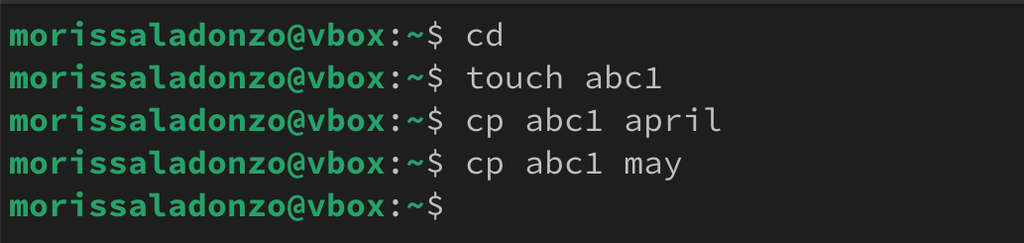

Создание файлов abc1, april и may

## Работа с файлами и каталогами

Создаю каталог monthly и копирую april и may в нем исползуя cp. Проверяю с ls:

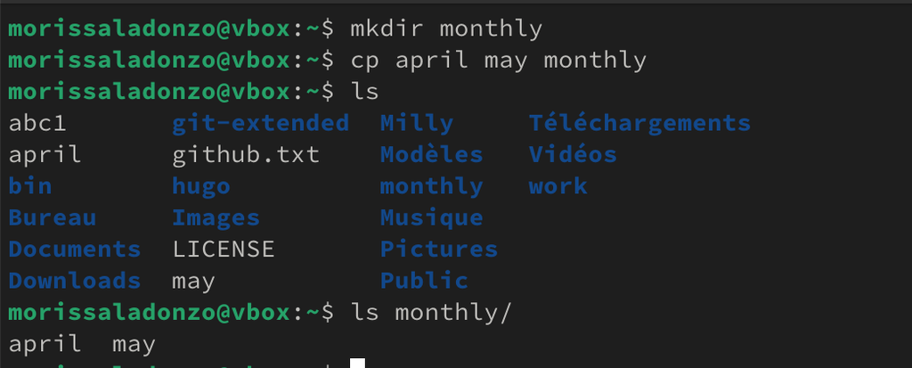

Создание monthly

## Работа с файлами и каталогами

Копирую каталог monthly в каталог monthly.00 с помощью опции cp -r:

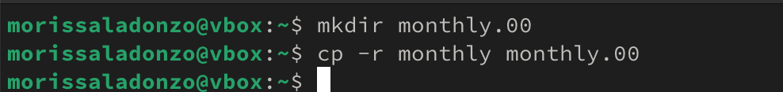

копирование каталога monthly

## Работа с файлами и каталогами

Изменяю название файла april на july в домашнем каталоге и перемещаю файл july в каталог monthly.00:

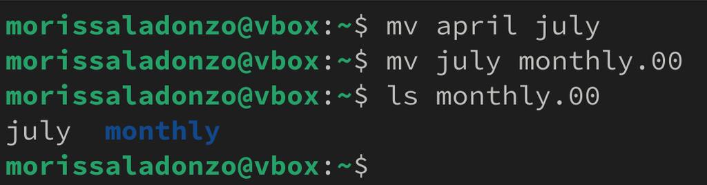

Перемещение файла july

## Работа с файлами и каталогами

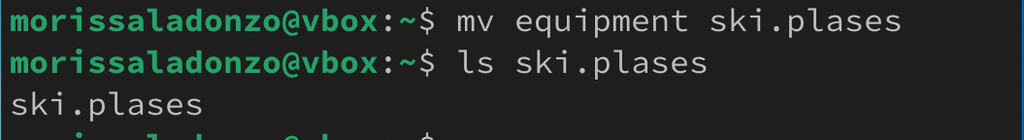

Перемещение файла equipment

## Работа с файлами и каталогами

Переименую файл ~/ski.plases/equipment в ~/ski.plases/equiplist и копирую abc1 в каталог ~/ski.plases, назову его equiplist2:

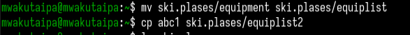

Переименование файла /equipment

## Работа с файлами и каталогами

Создаю каталог с именем equipment в каталоге ~/ski.plases и перемещаю файлы ~/ski.plases/equiplist и equiplist2 в каталог ~/ski.plases/equipment:

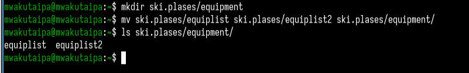

Создание каталога equipment, перемещение файлов

## Работа с файлами и каталогами

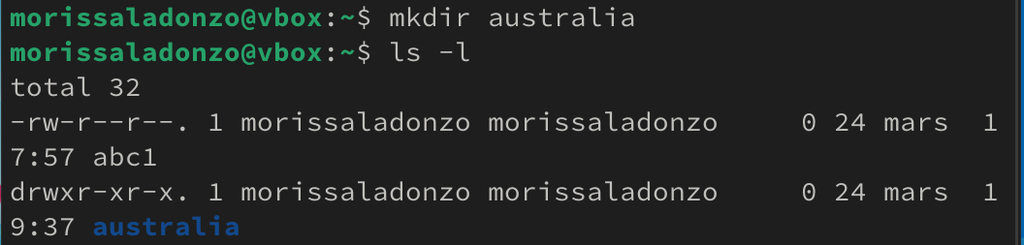

Создание australia

## Работа с файлами и каталогами

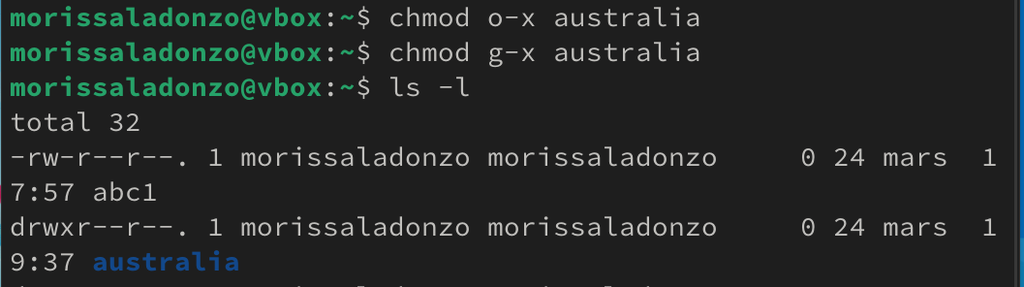

Удаление права

## Работа с файлами и каталогами

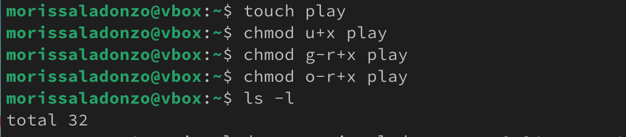

Измениеие прав

## Работа с файлами и каталогами

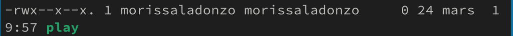

Проверка изменений

## Работа с файлами и каталогами

Изменяю права доступа к файлу feathers и проверяю:

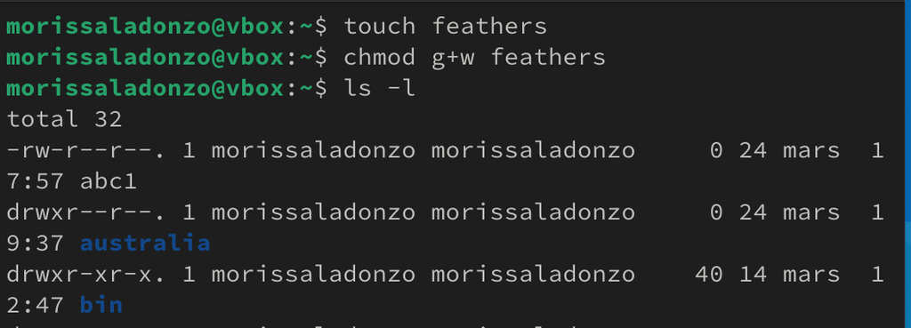

Измениеие прав к файлу feathers

## Работа с файлами и каталогами

Смотрю содержимое файла /etc/passwd:

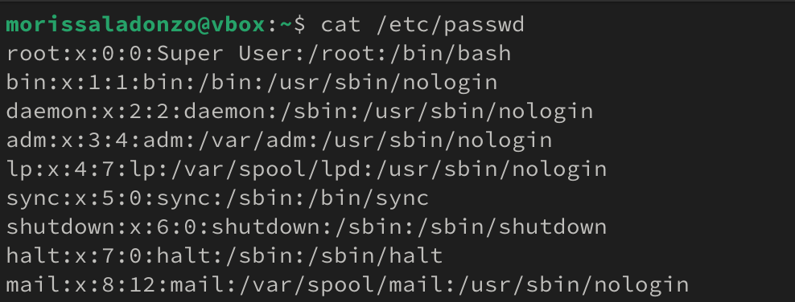

команда cat

## Работа с файлами и каталогами

Лишаю пользователя файла ~/feathers права на чтение:

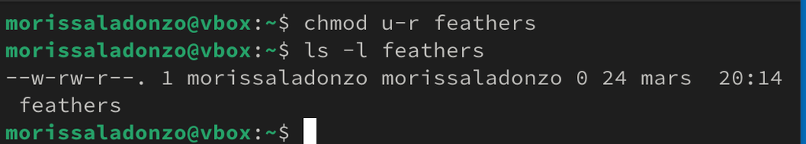

Лишение права на читение

## Работа с файлами и каталогами

Когда я попытаюсь просмотреть файл ~/feathers командой cat, система запрешает мне:

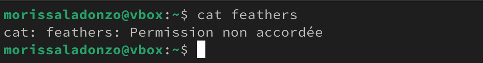

Посмотра файла feathers

## Работа с файлами и каталогами

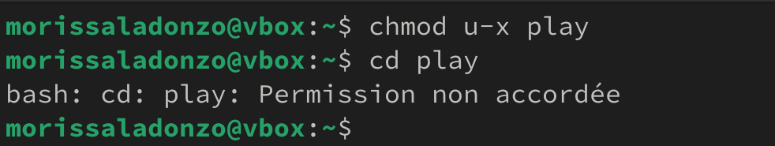

Лишение права на выполнение

## Работа с файлами и каталогами

Даю владельцу каталога ~/play право на выполнение:

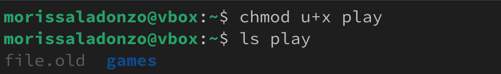

## Работа с файлами и каталогами

С помощью man прочитаю по mount — утилита командной строки в UNIX-подобных операционных системах. Применяется для монтирования файловых систем.

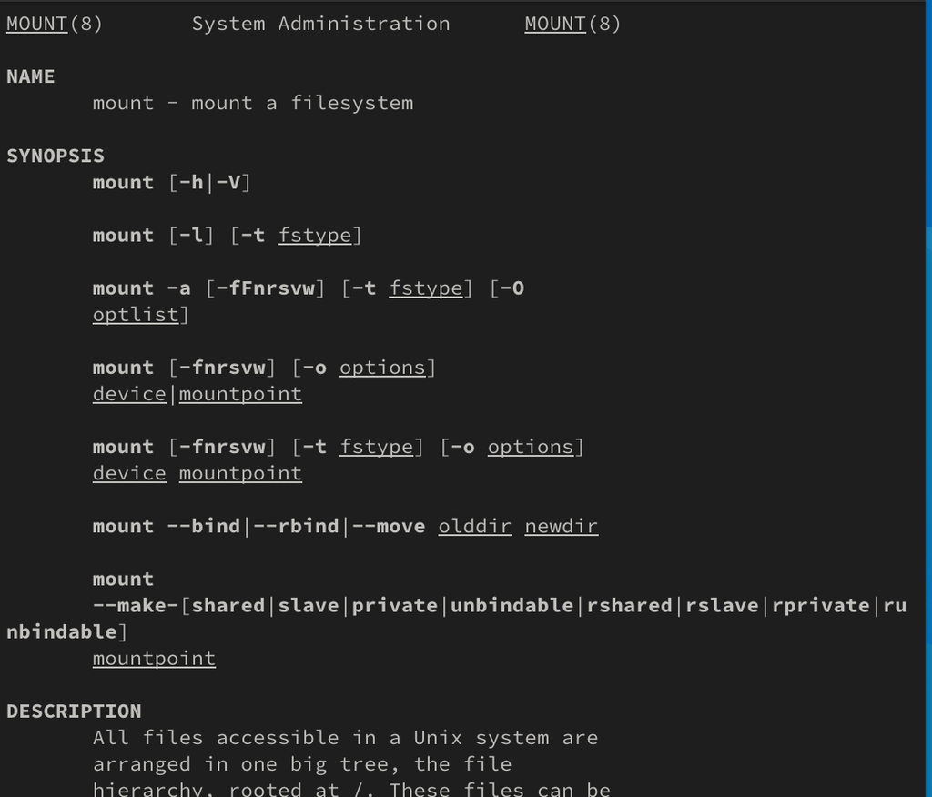

mount